# Survival Analysis Notes

Callum Arnold

2021-10-11

# British Journal of Cancer Tutorial Series

## Part 1 (Clark et al. 2003a)

- Often true time to event is not known (event hasn’t occurred at end of follow up)
- Survival data rarely normally distributed
  - Typically many early events and few late ones

### Censoring

- Survival times unknown for subset of study group
- Censoring can happen in a number of ways
  - Patient has not yet experienced outcome by end of study period
    - **Right censoring**
  - Patient is lost to follow up during study period
  - Patient experiences different event making follow up impossible
- Underestimates the true time to event
- **Left censored**
  - If we observe presence of a state/condition but don’t know when it occurs
  - We know the start point in this situation e.g. cancer reoccurence following surgery, as we know their surgical date
- **Interval censored**
  - Observe patients at intervals, and some may be lost to follow up between intervals, or time between intervals is large such that a person develops disease within the interval and precise onset can’t be known
- Most data is right censored, but methods exist for all types of censoring

### Illustrative Studies

- Generally good to choose end-point that can’t be mis-specified i.e. all-cause mortality vs mortality from specific condition

### Survival and Hazard

- **Survival probability** (*survival function*) $S(t)$
  - Probability an individual survives from the time origin to specified future time *t*
  - Reflects the cumulative non-occurence
- **Hazard** $h(t)$ or $\lambda(t)$
  - Probability that an observed individual has an event at time *t*, i.e., the instantaneous event rate for an individual who has survived to time *t*
  - Hazard relates to the incident event rate

### Kaplan-Meier Survival Estimate

- Non-parametric estimate from observed survival times
  - Both censored and non-censored
- *Assuming independent events*, multiply probabilities of surviving from one interval to the next to get the cumulative survival probability

$$\begin{equation}
\begin{split}
S(t_j) &= S(t_{j-1}) \left(1 - \frac{d_j}{n_j}\right) \\
\text{where}: n_j &= \text{# people alive just before } t_j \\
d_j &= \text{# of events at } t_j
\end{split}
\tag{1}
\end{equation}$$

- For censoring, can think of as inputting $d_j = 0$ and reducing $n_j$ by 1 (assuming one individual was censored at time $t_j$), resulting in $S(t_j) = S(t_{j-1})$
- Often patients lost to follow-up/alive at end of study period, so CIs are wider than earlier making for difficulty in interpretation
  - May want to curtail x-axis for this reason
- For low incidence events, plotting cumulative incidence instead of cumulative survival can be useful

### Hazard and Cumulative Hazard

- Relationship between survival and hazard given by equation

$$h(t) = - \frac{d}{dt}[\log S(t)] \tag{2}$$

- No simple way to estimate $h(t)$
  - Instead need to estimate the **cumulative hazard** $H(t)$

$$\begin{equation}
\begin{split}
H(t) &= \int h(t) \, dt \\
&= - \log [S(t)]
\end{split}
\tag{3}
\end{equation}$$

- Cumulative hazard can be though of as the number of events to be expected for each individual by time $t$ if the event was a repeatable process
- Cumulative hazard used to estimate $h(t)$, and as a diagnostic tool of model validity
- **Nelson-Aalen estimator** is a simple non-parametric estimate of $H(t)$
- Can also estimate hazard by assuming survival times follow a specific distribution (parametric estimation), for example:
  - Constant hazard (e.g. healthy individuals) = exponential distribution
  - Strictly increasing (e.g. leukaemia patients)/decreasing (e.g. patients recovery from surgery) hazard = Weibull
  - Increasing then decreasing log-Normal (e.g. TB patients)

### Non-parametric Tests Comparing Survival

- Logrank test most widely used to compare curves
  - Calculates at each event time, for each group, expected number of events since previous if no difference between groups, summed over all event times, giving total expected number of events for each group
  - $\chi^2$ test for observed vs expected in each group with $g-1$ degrees of freedom where $g$ is the number of groups (survival curves)
  - When only 2 groups, is $H_0$ that the **hazard ratio** = 1
    - Usually best to estimate with regression e.g., Cox regression, but can calculate with observations/estimated
  - More robust than comparing medians, but lack of effect size is a limitation
- If natural order, can do a test for trend
  - Compare to $\chi^2$ distribution with 1 df

### Some Key Requirements for the Analysis of Survival Data

- Standard methods require **noninformative censoring**
  - Censored individuals shouldn’t differ in their chance of experiencing an event e.g. informative when patients withdraw from trial due worsening clinical condition
- Must have sufficient follow up time to capture enough events
  - Sufficient power for test
- Good estimate of follow up time is the **reverse KM estimator**
  - Censoring is the event of interest
- Unequal of follow up between groups can bias analysis
- Need to take into account **cohort effects**
  - Assumption of homogeneity of treatment/other factors during study period may not hold e.g. long study period of cancer patients and detection methods improve so cases detected earlier in disease progression (not accounted for by groups)
- Consistency in methods between multiple participating centres

## Part 2 (Bradburn et al. 2003a)

### The Need for Multivariate Statistical Modelling

- Logrank test only provides p-value, not an estimate of effect size
  - We need a statistical model to do this, and account for covariates
- Two main approaches
  - Proportional hazards e.g. semi-parametric Cox model and fully parametric approaches
  - Accelerated failure time models

### The Cox (“Semi-parametric”) Proportional Hazards Model

- Regression model that describes the relation between event incidence (expressed by hazard function) and covariates

$$h(t) = h_0(t) \times \exp\{b_1 x_1 + b_2 x_2 + ... + b_p x_p \} \tag{4}$$

- Baseline hazard ($h_0(t)$) estimated non-parametrically, so survival times are not assumed to follow a distribution
- Effectively a linear regression of the logarithm of the hazard on the covariates $x_i$ with coefficients $b_i$
  - Covariates act manipulatively on hazard
- Key assumption
  - The hazard in any group is a **constant multiple** of the hazard in the other groups i.e. **proportional hazards,** therefore the hazard curves cannot cross
    - Often appropriate assumption for survival data, but must be confirmed
- $\exp(b_i)$ are the **hazard ratios**
  - HR > 1 means increased hazard of the event i.e. decreased survival time

### Parametric PH Models

- Same interpretation of regression results as Cox model, but assumes survival times and hazards follow a distribution
- Assumes proportional hazards
- Most common distributional assumptions
  - Exponential
  - Weibull
  - Gompertz

### Comparison of the Two PH Approaches

- Sometimes difficult to identify appropriate distribution of survival times
- Parametric model more informative than Cox model when have correct distribution
  - Straightforward to derive hazard function and obtain predicted survival times
  - Slightly more *efficient* i.e. smaller standard errors
- For either to be valid:
  - Covariate effect needs to be at least approximately constant throughout study period
  - Proportionality assumption holds

### Interpreting the PH Model: Beyond the Hazard Ratio

- Useful to estimate predicted survival proportion at a given time point for a group

$$S(t) = S_0(t) ^{\exp\{b_1 x_1 + b_2 x_2 + ... + b_p x_p \}} \tag{5}$$

### Accelerated Failure Time Models

$$\begin{equation}
\begin{split}
S(t) &= S_0 (\varphi t) \\
&= S_0 \left(\exp\{b_1 x_1 + b_2 x_2 + ... + b_p x_p \} t \right)
\end{split}
\tag{6}
\end{equation}$$

- $S_0(t)$ is the baseline survivor function and $\varphi$ is the **accelerator** **factor**
- The effect of the covariate is to stretch or shrink the survival curve along the time axis by a constant relative amount, $\varphi$
- The AFT model is commonly rewritten as being log-linear with respect to time

$$\begin{equation}
\begin{split}
\log(T) &= b_1 x_1 + b_2 x_2 + ... + b_p x_p + \varepsilon \\
\text{where}: \varepsilon &= \text{residual variability in survival times}
\end{split}
\tag{7}
\end{equation}$$

- Survival times multiplied by a constant effect
- $\exp(b_i)$ are **time ratios**
  - >1 for a covariate = increases the time to event
- When survival times follow Weibull, AFT and PH models are the same
  - Interpretation of effect sizes differs - time vs hazard ratios
- Normal distributional assumptions in AFT models:
  - Log-Normal
  - Log-Logistic
  - Generalised Gamma
  - Weibull
- Can implement semi-parametric AFT
  - Baseline survivor function is estimated non-parametrically
- Assumptions:
  - Appropriate distribution
  - Covariate effects assumed to be constant and multiplicative on the timescale i.e. impacts on survival by a constant factor

### Which Model Should We Use: PH or AFT?

- Initially, which fits the data better?
- Assuming both fit similarly:
  - Norm within field i.e. ease of comparability if HRs common vs TRs
  - Parametric approach of AFT offers more in the way of prediction
  - TRs arguably more interpretable than HRs

### Other Approaches

- More straighforward to incorporate covariates using stratified survival analysis
  - Use logrank or similar method to compare within strata, and combined for overall comparison adjusted for the strata e.g. stage of disease
  - No distributional assumptions made and simple interpretation
  - Only applicable with categorical variables and for few covariates
  - Does not quantify effect, and only p-value for variable of primary interest
  - Good for exploratory analysis

#### Aalen’s additive hazard model

- Assumes covariates impact additively on baseline hazard, but effects are not constrained to be constant
  - Impact can vary over time

$$h(t) = h_0(t) + b_1(t) x_1 + b_2(t) x_2 + ... + b_p(t) x_p \tag{8}$$

- Not simple to estimate baseline hazard non-parametrically, so need to use cumulative baseline, as well as estimating cumulative additional hazards as the regression coefficients

$$B_i(t) = \int_0^t b_i(u) du \tag{9}$$

- Plotting $B_i(t)$ is sometimes called Aalen plots, and the slope can be used to infer the relative increase in hazard at time $t$, but not the absolute increase ($b_i(t)$)
  - Can be used to informally assess PH assumption
- Difficult to interpret and $B_i(t)$ coefficients can change rapidly over time so no single effect size estimate

## Part 3 (Bradburn et al. 2003b)

### Choice of Covariates

- Need sufficient *number of events (not participants)* for power, especially with variable selection
  - Suggested at least 10 events for each covariate, otherwise coefficients will be biased
    - Including for interactions!
- Possible reasons to use a multivariable model:
  - Single factor under investigation, but other (nuisance) factors exist that need to be accounted for
  - Multiple factors of known relevance under investigation
  - Multiple factors are potentially associated with survival, possibly with additional known factors
    - Care must be taken to account for multiple testing issues that inflate significance
- Stepwise variable selection is a common *semiautomated* method used
  - Models may lack clinical significance, and prone to overfitting
- If used for predicting future survival patterns, need to ensure robust effect sizes
  - Bootstrap sampling common

### Assessing the Adequacy of a Model

- Need to assess **goodness of fit** i.e., predicted outcomes of a groups should be similar to observed
  - Most methods residual methods difficult to understand due to censoring
    - Residuals tend to be skewed and need smoothing functions applied for interpretation
  - Overall adequacy can be assess using Cox-Snell residuals
  - Suggested methods of assessing model fits with residuals:

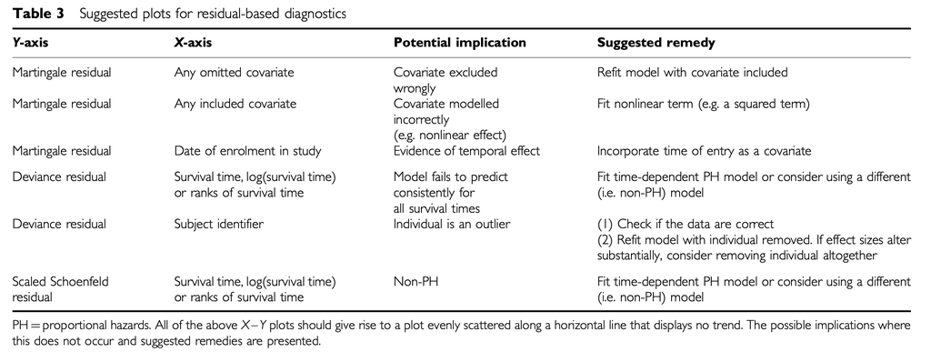

- For parametric models, selecting the correct distribution is key
  - The shape of the hazard is the most distinguishing feature - especially useful if known *a priori*
    - Weibull and Gompertz assume hazard is always increasing or decreasing
    - Log-Logistic used when hazard rises to a peak then decreases, or always decreases
      - Log-Normal and Generalized Gamma preferable when hazard rises to a peak then decreases
    - Exponential assumes constant hazard over time
    - For all, the shape of the distributions depend on **hyperparameters** (**ancillary** **parameter**) estimated from the data
    - Can plot smoothed empirical hazard/cumulative hazard against model estimated hazards
    - Can also plot log(-log(survival)) plots
    - AIC/BIC can compare model viability
      - Cox model produces a partial likelihood, so cannot be compared to fully parametric models using AIC/BIC
  - Parametric AFT models are arguably more flexible than Cox model, so may also be used when fully parametric models can’t
- Simple test of model adequacy is to compare model survival predictions to KM survival curve
- More formal measure compares observed and expected events in different *risk groups*
  - **Predicted risk (prognostic index - PI)** are calculated for each patient, risk groups are constructed by ranking PIs, and a score test is applied to the differences between observed and expected events in risk groups

$$PI = b_1 x_1 + b_2 x_2 + ... + b_p x_p \tag{10}$$

- Predicted survival curves can be misleading when multiple associated covariates, especially when multicollinearity present
  - Fixing all other estimates to mean values ignores these correlations
  - Use PI test instead

### Assessing Whether PH is Appropriate

- Empirical hazard function generally not well estimated, so better to use **log(-log(survival))** plots
  - Log of cumulative hazards against log of time for assessing PH assumption
    - Remember $H(t) = -\log[S(t)]$
  - Should result in parallel lines
    - May not due to lack of proportionality, *or* missing important covariate\
    - Either way, suggests inadequate model
  - Weibull or Exponential parametric models should result in straight lines
- In Cox PH framework, scaled Schoenfeld residuals test, linear correlation test, and time-dependent covariate test most powerful diagnostic tests for proportionality
  - First 2 assess residuals over time
  - Last assesses whether the covariate coefficients change in time i.e., nonconstant hazard ratio
    - Appealing as assesses *both* nonproportionality *and* model validity
- Can sometimes use a time-dependent covariate Cox PH model when PH assumption violated
  - Interactions between covariates and log time

### Assessing Whether An AFT Model is Adequate

- **Quantile-quantile (Q-Q) plots** of the times of the survival percentiles should be a straight line of slope $\varphi$ passing through $(0, 0)$.
  - Good first examination, but can’t account for non-linearity due to inappropriate/omitted covariates
- Time-dependent covariate models can be used

## Part 4 (Clark et al. 2003b)

### Categorising Continuous Variables?

- Occasionally good reasons to categorise variables, so do the following:
  - Use predetermined cut-points, preferably with clinical meaning
    - Don’t choose cut-points to minimise p-values
  - Use 2+ categories to reduce loss of information and allow linearity assessment
  - Ensure groups sizes are adequate (individuals + events)
- Think if smoothing splines would be more appropriate if nonlinear associations

### Multiple Measurements for the Same Covariate

- Requires **time-dependent (updated) covariate** methods
  - The value of the covariate changes during the study period e.g. non-smoker starts smoking
- Updated hazard formula in the PH model:

$$h(t) = h_0(t) \exp[b_1 x_1(t)] \tag{11}$$

- Harder to use time-dependent AFT models
- Can also get **time-dependent coefficients** i.e. $h(t) = h_0(t) \exp[b_1(t) x_1]$
  - The effect of the covariate changes during the study period
- Requires a large amount of data
- Have to be confident that the collection process itself isn’t dependent on clinical progress

### Informative Censoring

- *Ad hoc* method of sensitivity analysis
  - Assign varying survival times to censored individuals and examine differences
  - Works best when few censored, but also less bias then
- Assume all censored individuals follow same treatment e.g. patients lost to follow-up in smoking cessation trial all considered to be continuing smokers
- Competing risks or mixture models can be used when individual experiences different defined event which are explicitly modelled

### Missing Covariate Data

- Multiple imputation methods preferable to alternatives
- Sensitivity analysis should be conducted to compare imputation results against complete case etc

### Variable Selection

- Start with known prognostic factors and those specifically required for study aims
- Backwards selection is best of the selection strategies as full model is the only one with accurate standard errors and p-values
- Lasso and ridge regression possibilities
- Use bootstrap methods to compare stability and predictive ability of the full model vs reduced model

### Measuring the Predictive Ability, and Model Validation

- Useful models require both internal and external validity
- *c-index* used to determine discrimination
- Calibration can be quantified using an estimate of slope shrinkage
- Can use training and test data for validation
- Bootstrapping or LOOCV likely more useful for validation

### Analysis with Unmeasured Factors

- Inappropriate when vital information is missing e.g. cancer stage
- Possible that some individuals have shared exposure that is unmeasured e.g. environmental exposures for a family
  - Arises in cluster randomised trials and multicentre trials
  - Considered to be **multilevel** so need to examine variation within and between groups
    - Use **random effects (frailty)** model to allow covariate effects to vary across groups
      - Can also be considered to apply to the individual relating to unmeasured variables, for example
      - Requires precise knowledge of the frailty distribution, which is often not available

### Artificial Neural Networks and Regression Trees

- ANNs work by having a/multiple latent (hidden) layer(s) between the input (covariates) and output (survival probability)
  - The relative importance of the latent variables determines survival
  - Can more easily incorporate complex covariate-survival relationships than Cox regression
  - High chance of overfitting
  - Lack of interpretation
  - Difficulty handling censored survival times
  - Usually not better than standard techniques, but often misused
- CARTs are easily interpretable and rely on fewer distributional assumptions
  - Particularly useful when interactions
  - Have to decide threshold to categorise continuous variables and correct for multiple testing and overfitting
    - Same issues as forward selection
  - Doesn’t offer effect size estimates as focuses on discrimination

### Different Types of Events or Repeated Events

- Competing risks analysis
  - Seperate time to events can be misleading and KM overestimates proportion of subjects experiencing each event
    - Cumulative incidence method useful to overcome this
      - Overall event probability at time $t$ is the sum of the event-specific probabilities
  - Generally implemented by entering each patient once per event type
    - Experiencing a different event = censoring time
- Multiple events of the same type
  - Common to use the first event only
    - Ignores information
  - **Conditional model**
    - Time broken up into segments by event i.e. only at risk of event 2 after you’ve experienced event 1
    - Can model starting at:
      - Beginning of the study
      - The time of the first event
  - **Marginal model**
    - Each event is a separate process i.e. time starts at the beginning of the follow-up for each individual
    - Considered to be at-risk for all events, regardless of number of previous events e.g. patient can be at risk of event 4, even if they were lost to follow up at the 2nd
- **Independent increment model**
  - Similar to conditional, but doesn’t account for the number of previous events experienced by a patient
    - Conditional and marginal preferable for this reason

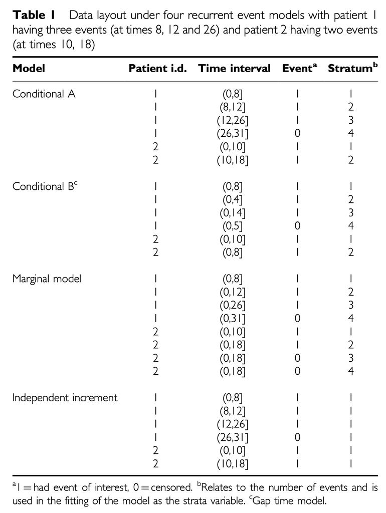

- All entered as one patient record per event number
- All applied within usual Cox or AFT model framework
  - 2 exceptions from usual fitting
    - Cluster effect used to adjust s.e. due to patients repeated
    - Stratified analysis (except increment model) by event type (competing risks) or number (recurring events)
      - Interactions between covariates and strata can be assessed

# Interval Censored Data - `{icenReg}` (Anderson-Bergman 2020)

## Introduction

- Interval censoring occurs when a response is known up to an interval e.g. tests negative at visit 1 and positive at visit 2
- When intervals are short in relation to question of interest e.g., onset of T2 diabetes, bias by ignoring interval censoring minimal
- Usually use notation assuming half-open, half-closed intervals i.e. $t_i \in (l_i, r_i]$ is the response interval
  - Exception when using $(t_i, t_i]$ stating that the event $i$ is uncensored at time $t_i$, despite it being an undefined interval
    - Allows for left- ($l_i = 0$), right- ($r_i = \infty$), interval-, uncensored ($l_i = r_i$), and other ($0 < l_i < r_i < \infty$) observations
- **Turnbull’s Estimator (Non-Parametric Maximum Likelihood Esimator)** is a classic model allowing for interval censoring
  - Generalized KM curve
    - Solutions not in closed form, unlike KM, so computational efficient algorithms required
- Cox PH and Proportional Odds models are common both semi-parametric models
  - Can convert the Cox PH survival function to PO model

$$\begin{equation}
\begin{split}
S(t|\mathbf{X}, \beta) &= S_o(t)e^{\mathbf{X}^T \beta} \\
\text{Odds}(S(t|\mathbf{X}, \beta)) &= e^{\mathbf{X}^T \beta} \ \text{Odds}(S_0(t)) \\
\frac{S(t|\mathbf{X}, \beta)}{1 - S(t|\mathbf{X}, \beta)} &= e^{\mathbf{X}^T \beta} \frac{S_o(t)}{1 - S_0(t)}
\end{split}
\tag{12}
\end{equation}$$

- Difficult to estimate regression parameters without estimating baseline distribution
  - Except in Cox PH with right-censored data
  - Use Turnbull estimator to keep the model semi-parametric i.e. no need to estimate distribution
    - Difficult to compute as up to $n$ baseline parameters with no closed form solution
- For small datasets, intervcal censoring can result in non-concave log likelihood function
  - Usually locally concave near mode for reasonable sized data

## Fitting Models using `{icenReg}`

### Non-Parametric Models

- For smaller datasets, use `{interval}` package instead of `icenReg::ic_np()`
  - Allows for non-parametric tests e.g. log-rank statistic
- 2 lines produced for survival curve
  - NPLME not always unique for interval censored data, so everything between bounds has the same likelihood

### Semi-Parametric Models

- Bootstrap samples used for inference on regression parameters
  - Likely not valid for baseline distribution

## Inspecting Model Fit

### Examining Baseline Distribution

- Even if parametric fit used for inference (baseline distribution required), such as CIs for median, semi-parametric useful for assessing model fit
  - Can’t examine typical residuals or histograms with interval censored data
- If semi-parametric and parametric fits similar, good indication of parametric appropriateness

### Examining Covariate Effect

- Both parametric and semi-parametric models make assumptions about the form of the covariate effect (like GLM link function)
- PH assumption checked by crossing of KM curves
  - Adapt to NPLME curves with interval censoring
  - Can be generalized to proportional odds assumption
- Transformation check (difference in transformed survival should be constant)
  - PH = log-log transformation plots ($\log(-\log[S(t)])$)
  - PO = logit transformation plots ($\log\left[\frac{S(t)}{1-S(t)}\right]$)
  - Can be used to see if PH or PO more appropriate

# Pairwise Survival Analysis of Infectious Disease Transmission Data (Kenah 2021)

## Introduction

- Complicated by “dependent happenings”
- Consider failure times in ordered pairs $ij$ (infected $i$, susceptible $j$) instead of failure times in individuals
  - **Pairwise survival analysis**
- Can write the survival function of the contact interval distribution (distribution of $\tau_{ij}$)
  - This is the **secondary attack rate**

$$\begin{equation}
\begin{split}
S_{ij}(\tau) &= \Pr(\tau_{ij} > \tau) \\
\text{where: } \tau_{ij} &= \text{contact interval of } ij \text{ i.e., onset of infectiousness in } i \text{ to infectious contact to } j
\end{split}
\tag{13}
\end{equation}$$

- We can use the survival function to write the cumulative and instantaneous hazard functions

$$\begin{equation}
\begin{split}
h_{ij}(\tau) &= H_{ij}^{'} \\
&= - \frac{S_{ij}^{'}(\tau)}{S_{ij}(\tau)} \\
\text{where: } H_{ij}(\tau) &= - \ln[S_{ij}(\tau)]
\end{split}
\tag{14}
\end{equation}$$

# References

Anderson-Bergman, Clifford. 2020. “Using icenReg for Interval Censored Data in R V2.0.9.”

Bradburn, M. J., T. G. Clark, S. B. Love, and D. G. Altman. 2003a. “Survival Analysis Part II: Multivariate Data Analysis an Introduction to Concepts and Methods.” *British Journal of Cancer* 89 (3): 431–36. https://doi.org/10.1038/sj.bjc.6601119.

———. 2003b. “Survival Analysis Part III: Multivariate Data Analysis Choosing a Model and Assessing Its Adequacy and Fit.” *British Journal of Cancer* 89 (4): 605–11. https://doi.org/10.1038/sj.bjc.6601120.

Clark, T. G., M. J. Bradburn, S. B. Love, and D. G. Altman. 2003a. “Survival Analysis Part I: Basic Concepts and First Analyses.” *British Journal of Cancer* 89 (2): 232–38. https://doi.org/10.1038/sj.bjc.6601118.

———. 2003b. “Survival Analysis Part IV: Further Concepts and Methods in Survival Analysis.” *British Journal of Cancer* 89 (5): 781–86. https://doi.org/10.1038/sj.bjc.6601117.

Kenah, Eben. 2021. “Pairwise Survival Analysis of Infectious Disease Transmission Data.” In *Handbook of Infectious Disease Data Analysis*, edited by Leonhard Held, Niel Hens, Philip O’Neill, and Jacco Wallinga, First, 221–44. Handbook of Modern Statistical Methods. Routledge & CRC Press.